# Assigning ASVs with DADA2

Mar Schmidt

March 05, 2025

# Goals of this file

1. Infer Errors on forward and reverse reads individually.
2. Identy ASVs on forward and reverse reads separately, using the error model.
3. Merge forward and reverse ASVs into “contiguous ASVs”.
4. Generate the ASV count table
5. Trim ASV Lengths
6. Remove Chimeras.
7. Assign Taxonomy with the Silva Database.
8. Write out relevant files: `asv_table`, `asv_fastas`, `tax_table`, and `sample_data`.

#### Input that we need:

1. Filtered `fastq.gz` files generated from `01_QualityTrimming.Rmd`.
2. Sample name vector

#### Output that we need:

1. ASV Count Table: `asv_table`
2. ASV fasta file: for building phylogenetic trees later.
3. Taxonomy Table `tax_table`
4. Sample Information: `sample_data` track the reads lots throughout DADA2 workflow.

# Setting up the environment

## Set the seed

```r
# Any number can be chosen
set.seed(238428)
```

### Timing of Script

I’d like to know how long this file took to run, which we will record at the end of the script.

```r
# What time did we start running this script?
start_time <- Sys.time()
start_time
```

```
## [1] "2025-03-05 13:48:35 EST"
```

## Load Libraries

```r
# Efficient package loading with pacman
# Don't forget to install pacman and DT if you don't have it yet. :)
pacman::p_load(tidyverse, BiocManager, devtools, dada2,
               phyloseq, patchwork, DT, install = FALSE)
```

## Load in Filtered fastqs

```r
# Place filtered reads into filtered_fastqs_path
filtered_fastqs_path <- "data/01_DADA2/02_filtered_fastqs"

# Intuition Check
filtered_fastqs_path
```

```
## [1] "data/01_DADA2/02_filtered_fastqs"
```

```r
# create 2 vectors: filtered_forward_reads & filtered_reverse_reads
filtered_forward_reads <-
  list.files(filtered_fastqs_path, pattern = "_R1_filtered.fastq.gz",
             full.names = TRUE)

# Intuition Check
length(filtered_forward_reads)
```

```
## [1] 96
```

```r
# reverse reads
filtered_reverse_reads <-
    list.files(filtered_fastqs_path, pattern = "_R2_filtered.fastq.gz",
             full.names = TRUE)

# Intuition Check
head(filtered_reverse_reads)
```

```
## [1] "data/01_DADA2/02_filtered_fastqs/022um-Control_R2_filtered.fastq.gz"
## [2] "data/01_DADA2/02_filtered_fastqs/20210602-MA-ABB1F_R2_filtered.fastq.gz"
## [3] "data/01_DADA2/02_filtered_fastqs/20210602-MA-ABB1P_R2_filtered.fastq.gz"
## [4] "data/01_DADA2/02_filtered_fastqs/20210602-MA-ABB1W_R2_filtered.fastq.gz"
## [5] "data/01_DADA2/02_filtered_fastqs/20210602-MA-ABS1F_R2_filtered.fastq.gz"
## [6] "data/01_DADA2/02_filtered_fastqs/20210602-MA-ABS1P_R2_filtered.fastq.gz"
```

## Assign Sample Names

```r
# Create vector of sample names from the filenames
sample_names <- sapply(strsplit(basename(filtered_forward_reads), "_"), `[`,1)

# Intuition Check
head(sample_names)
```

```
## [1] "022um-Control"     "20210602-MA-ABB1F" "20210602-MA-ABB1P"
## [4] "20210602-MA-ABB1W" "20210602-MA-ABS1F" "20210602-MA-ABS1P"
```

# Error Modelling

## How does it work?

This is the step along the workflow where we try to estimate what is a *mistake* from technological sequencing error versus what is *true biological variation*. Therefore, this step is another critical step that we need to be mindful of! This is also what makes DADA2 unique!

Specifically, we will infer error rates for all possible *transitions* within purines and pyrimidines (A<>G or C<>T) and *transversions* between all purine and pyrimidine combinations. The error model is learned by alternating estimation of the error rates and inference of sample composition until they converge. It starts with abundant sequences first and then goes to less abundant sequences. It will:

1. Starts with the assumption that the error rates are the maximum (takes the most abundant sequence (“center”) and assumes it’s the only sequence not caused by errors).
2. Compares the other sequences to the most abundant sequence.
3. Uses at most 10<sup>8</sup> nucleotides for the error estimation. (Though, sometimes we increase this parameter in the case of binned sequencing quality scores.)
4. Uses parametric error estimation function of loess fit on the observed error rates.

## Important Notes

**First, every individual sequencing run needs to have it’s own and separate error model!** This is because every sequencing run is unique—even if the flow cell and DNA/samples are *exactly the same*.

While you can combine multiple datasets together after running them through DADA2, if you’d like to limit bias and combine data sets from multiple sequencing runs, it is ideal to do the following:

1. Use the exact same DNA extractions and library prep (*e.g.* same primer sets).
2. Perform the exact same `filterAndTrim()`, with equivalent parameters between sequencing runs. This is because we need to have the exact same ASV length expected by the output of our filtering and trimming.
3. Assign ASVs on forward and reverse reads, merge them, and then once you have the ASV table from each sequencing run, you can merge them together.

But wait: *What contributes to sequencing error in different sequencing runs and why do we need to model errors separately per run with `learnErrors()` in dada2?* Remember the core principles of how Illumina sequencing works! Some things that contribute to this are:

1. Each sequencing run has a **unique timing for when clusters go out of sync** (*e.g.,* the drop in quality at end of reads, which is typical of Illumina sequencing. This decrease in read quality is especially true of older Illumina sequencing data and is improving with more recent technologies.
2. The **cluster density is impossible to replicate**. Therefore, the cluster density (and therefore sequence quality) will always be different between sequencing runs (even if it’s the same person/samples/sequencing facility!). This is getting easier to replicate with the newer flow cells (*e.g.,* patterned flow cells) but is not yet possible.
3. **PhiX spike-in will also vary between runs**, even if we try to make it the same! Therefore, the amount of heterogeneity on the flow cell will also be different, which further impacting the sequencing quality.
4. **Different locations on the flow cell can be impacted differently between runs.** Perhaps an air bubble can get in. Or, as mentioned above, the cluster density is higher and/or lower on a different run/flow cell. In the old, non-patterned flow cells, sometimes clusters can form nearby each other. However, this has been solved on the new, patterned flow cells where clusters have a specific distance between each other.

**Second, this step uses our quality scores, which is rapidly changing with new sequencing technologies!** Therefore, we need to be mindful of how we run our error models. The traditional error models were developed based on the 40 Phred scores that were generated by early Illumina Sequencing technologies. However, with the new binned quality scores, we need to incorporate new ways of error modeling and this is constanstly changing right now, which you can see in this [very active discussion on the DADA2 GitHub page](https://github.com/benjjneb/dada2/issues/1307).

Now, let’s consider the two types of Illumina data output and how it might inform our error modeling.

## Learn the Errors

### MiSeq Runs: 40 Phred Scores

Here, in the data we have sequenced here, we have Illumina MiSeq data with the traditional 40 Phred scores. Therefore, we can use the traditional `learnErrors()` command, which we will do below.

```r
# Forward reads
error_forward_reads <-
  learnErrors(filtered_forward_reads, multithread = 20)
```

```
## 101382028 total bases in 418934 reads from 72 samples will be used for learning the error rates.
```

```r
# Plot Forward
forward_error_plot <-
  plotErrors(error_forward_reads, nominalQ = TRUE) +
  labs(title = "Forward Read Error Model")

# Reverse reads
error_reverse_reads <-
  learnErrors(filtered_reverse_reads, multithread = 20)
```

```
## 100544160 total bases in 418934 reads from 72 samples will be used for learning the error rates.
```

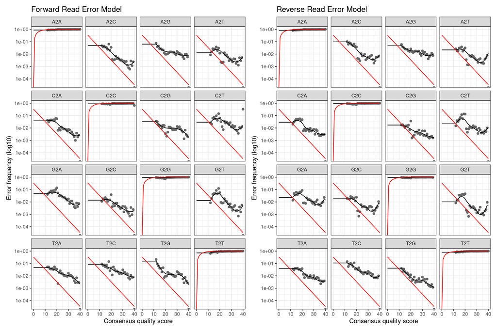

```r
# Plot reverse
reverse_error_plot <-
  plotErrors(error_reverse_reads, nominalQ = TRUE) +
  labs(title = "Reverse Read Error Model")

# Put the two plots together
forward_error_plot + reverse_error_plot
```

The above plot represents the error rates for each possible transition (A→C, A→G, …) in the forward reads (on the left) and the reverse reads (on the right).

Details of the plots above: - **Points**: The observed error rates for each consensus quality score.  
- **Black line**: Estimated error rates after convergence of the machine-learning algorithm.  
- **Red line:** The error rates expected under the nominal definition of the Q-score.

Similar to what is mentioned in the [DADA2 tutorial](https://benjjneb.github.io/dada2/tutorial_1_8.html): the estimated error rates (black line) are a “reasonably good” fit to the observed rates (points), and the error rates drop with increased quality as expected. We can now infer ASVs!

### NextSeq2000 Runs: Binned Quality Scores

*An important consideration!* There has been active discussion that the **newer binned quality scores from more recent Illumina technologies require many more bases to tune the error models** than the continuous quality scores from MiSeq to prevent spurious ASVs. For example, it’s strongly recommended that you play around with and *tune* your number of bases, however, using `1e10` is recommended for the class, as it’s likely this will give you enough data to model your error rates.

Before running your error rates here, one final consideration could be to remove blanks from the error model, which may have unique error rates.

If you work with binned quality scores, please read through this [DADA2 GitHub Issue](https://github.com/benjjneb/dada2/issues/1307). Specifically, there is a new note from **December 5th, 2024** (*note how recent this is!*) where the developers of DADA2 have proposed a new function to be included. You can also see in this issue that a community member has contributed a loess model to help tune the error model called `loessErrfun_mod`, which my lab has used in the past (since it was before December 5th, 2024)

Now, if you have binned quality scores, the DADA2 authors are suggesting the following for the error models:

```r
# Inform the model of the specific bins from the Illumina Sequencing run
binnedQs <- c(2, 11, 25, 37)

# Now, use those bins to create the Error Function
binnedQualErrfun <- makeBinnedQualErrfun(binnedQs)

# Finally, we can actually learn the errors
learnErrors(filts, errorEstimationFunction=binnedQualErrfun, multi=TRUE)
```

# Infer ASVs

**An important note:** What makes DADA2 so nice is that it infers ASVs separately on the forward and the reverse reads and then merges them afterwards. This is quite a different approach from how OTUs are identified in Mothur and also from UCHIME, oligotyping, and other OTU, MED, and ASV approaches.

```r
# Infer ASVs on the forward sequences
dada_forward <- dada(filtered_forward_reads,
                     err = error_forward_reads,
                     multithread = TRUE)
```

```
## Sample 1 - 8065 reads in 886 unique sequences.
## Sample 2 - 4658 reads in 1669 unique sequences.
## Sample 3 - 4630 reads in 2335 unique sequences.
## Sample 4 - 7056 reads in 3042 unique sequences.
## Sample 5 - 4623 reads in 2095 unique sequences.
## Sample 6 - 5346 reads in 2666 unique sequences.
## Sample 7 - 6172 reads in 2866 unique sequences.
## Sample 8 - 5522 reads in 2447 unique sequences.
## Sample 9 - 6997 reads in 2968 unique sequences.
## Sample 10 - 6649 reads in 3017 unique sequences.
## Sample 11 - 5924 reads in 2305 unique sequences.
## Sample 12 - 5656 reads in 2331 unique sequences.
## Sample 13 - 5191 reads in 2118 unique sequences.
## Sample 14 - 3726 reads in 2003 unique sequences.
## Sample 15 - 5792 reads in 2688 unique sequences.
## Sample 16 - 6788 reads in 3209 unique sequences.
## Sample 17 - 5823 reads in 3456 unique sequences.
## Sample 18 - 4449 reads in 2723 unique sequences.
## Sample 19 - 6397 reads in 3705 unique sequences.
## Sample 20 - 6798 reads in 2363 unique sequences.
## Sample 21 - 3473 reads in 1555 unique sequences.
## Sample 22 - 4580 reads in 1831 unique sequences.
## Sample 23 - 6133 reads in 2260 unique sequences.
## Sample 24 - 3523 reads in 1106 unique sequences.
## Sample 25 - 5298 reads in 2126 unique sequences.
## Sample 26 - 5460 reads in 2553 unique sequences.
## Sample 27 - 4220 reads in 2239 unique sequences.
## Sample 28 - 6192 reads in 2876 unique sequences.
## Sample 29 - 8672 reads in 3675 unique sequences.
## Sample 30 - 7446 reads in 3601 unique sequences.
## Sample 31 - 4373 reads in 2044 unique sequences.
## Sample 32 - 3145 reads in 611 unique sequences.
## Sample 33 - 4632 reads in 2251 unique sequences.
## Sample 34 - 9411 reads in 3870 unique sequences.
## Sample 35 - 4978 reads in 2168 unique sequences.
## Sample 36 - 6262 reads in 2867 unique sequences.
## Sample 37 - 4582 reads in 2007 unique sequences.
## Sample 38 - 6879 reads in 2856 unique sequences.
## Sample 39 - 5084 reads in 2429 unique sequences.
## Sample 40 - 6198 reads in 2663 unique sequences.
```

[output cut: 41 more lines]

```
## Sample 82 - 9489 reads in 3953 unique sequences.
## Sample 83 - 5876 reads in 2501 unique sequences.
## Sample 84 - 5746 reads in 2723 unique sequences.
## Sample 85 - 7327 reads in 3181 unique sequences.
## Sample 86 - 7995 reads in 3086 unique sequences.
## Sample 87 - 6385 reads in 2721 unique sequences.
## Sample 88 - 7833 reads in 4091 unique sequences.
## Sample 89 - 6890 reads in 2711 unique sequences.
## Sample 90 - 6247 reads in 1944 unique sequences.
## Sample 91 - 6521 reads in 2575 unique sequences.
## Sample 92 - 8805 reads in 974 unique sequences.
## Sample 93 - 6576 reads in 3040 unique sequences.
## Sample 94 - 6122 reads in 774 unique sequences.
## Sample 95 - 7105 reads in 3150 unique sequences.
## Sample 96 - 9564 reads in 958 unique sequences.
```

```r
typeof(dada_forward)
```

```
## [1] "list"
```

```r
# Grab a sample and look at it
dada_forward$`20211005-MA-CWS1P_R1_filtered.fastq.gz`
```

```
## dada-class: object describing DADA2 denoising results
## 243 sequence variants were inferred from 2889 input unique sequences.
## Key parameters: OMEGA_A = 1e-40, OMEGA_C = 1e-40, BAND_SIZE = 16
```

```r
# Infer ASVs on the reverse sequences
dada_reverse <- dada(filtered_reverse_reads,
                     err = error_reverse_reads,
                     multithread = TRUE)
```

```
## Sample 1 - 8065 reads in 1342 unique sequences.
## Sample 2 - 4658 reads in 1864 unique sequences.
## Sample 3 - 4630 reads in 2508 unique sequences.
## Sample 4 - 7056 reads in 3366 unique sequences.
## Sample 5 - 4623 reads in 2370 unique sequences.
## Sample 6 - 5346 reads in 2888 unique sequences.
## Sample 7 - 6172 reads in 3140 unique sequences.
## Sample 8 - 5522 reads in 2625 unique sequences.
## Sample 9 - 6997 reads in 3357 unique sequences.
## Sample 10 - 6649 reads in 3288 unique sequences.
## Sample 11 - 5924 reads in 2807 unique sequences.
## Sample 12 - 5656 reads in 2598 unique sequences.
## Sample 13 - 5191 reads in 2453 unique sequences.
## Sample 14 - 3726 reads in 2149 unique sequences.
## Sample 15 - 5792 reads in 2942 unique sequences.
## Sample 16 - 6788 reads in 3482 unique sequences.
## Sample 17 - 5823 reads in 3782 unique sequences.
## Sample 18 - 4449 reads in 3063 unique sequences.
## Sample 19 - 6397 reads in 3886 unique sequences.
## Sample 20 - 6798 reads in 2595 unique sequences.
## Sample 21 - 3473 reads in 1726 unique sequences.
## Sample 22 - 4580 reads in 2034 unique sequences.
## Sample 23 - 6133 reads in 2496 unique sequences.
## Sample 24 - 3523 reads in 1318 unique sequences.
## Sample 25 - 5298 reads in 2435 unique sequences.
## Sample 26 - 5460 reads in 2779 unique sequences.
## Sample 27 - 4220 reads in 2393 unique sequences.
## Sample 28 - 6192 reads in 3135 unique sequences.
## Sample 29 - 8672 reads in 4071 unique sequences.
## Sample 30 - 7446 reads in 4021 unique sequences.
## Sample 31 - 4373 reads in 2281 unique sequences.
## Sample 32 - 3145 reads in 758 unique sequences.
## Sample 33 - 4632 reads in 2446 unique sequences.
## Sample 34 - 9411 reads in 4257 unique sequences.
## Sample 35 - 4978 reads in 2363 unique sequences.
## Sample 36 - 6262 reads in 3169 unique sequences.
## Sample 37 - 4582 reads in 2176 unique sequences.
## Sample 38 - 6879 reads in 3121 unique sequences.
## Sample 39 - 5084 reads in 2621 unique sequences.
## Sample 40 - 6198 reads in 2946 unique sequences.
```

[output cut: 41 more lines]

```
## Sample 82 - 9489 reads in 4234 unique sequences.
## Sample 83 - 5876 reads in 2899 unique sequences.
## Sample 84 - 5746 reads in 2984 unique sequences.
## Sample 85 - 7327 reads in 3520 unique sequences.
## Sample 86 - 7995 reads in 3462 unique sequences.
## Sample 87 - 6385 reads in 3067 unique sequences.
## Sample 88 - 7833 reads in 4432 unique sequences.
## Sample 89 - 6890 reads in 2996 unique sequences.
## Sample 90 - 6247 reads in 2314 unique sequences.
## Sample 91 - 6521 reads in 3235 unique sequences.
## Sample 92 - 8805 reads in 1543 unique sequences.
## Sample 93 - 6576 reads in 3349 unique sequences.
## Sample 94 - 6122 reads in 1150 unique sequences.
## Sample 95 - 7105 reads in 3224 unique sequences.
## Sample 96 - 9564 reads in 1542 unique sequences.
```

```r
# Inspect
dada_reverse[1]
```

```
## $`022um-Control_R2_filtered.fastq.gz`
## dada-class: object describing DADA2 denoising results
## 9 sequence variants were inferred from 1342 input unique sequences.
## Key parameters: OMEGA_A = 1e-40, OMEGA_C = 1e-40, BAND_SIZE = 16
```

```r
dada_reverse[30]
```

```
## $`20210602-MA-SCS1P_R2_filtered.fastq.gz`
## dada-class: object describing DADA2 denoising results
## 219 sequence variants were inferred from 4021 input unique sequences.
## Key parameters: OMEGA_A = 1e-40, OMEGA_C = 1e-40, BAND_SIZE = 16
```

# Merge Forward & Reverse ASVs

Now, that we have identified our ASVs separately on both the forward and the reverse reads, let’s **merge** them together into contiguous (*aka* “contigs”) ASVs.

```r
# merge forward and reverse ASVs
merged_ASVs <- mergePairs(dada_forward, filtered_forward_reads,
                          dada_reverse, filtered_reverse_reads,
                          verbose = TRUE)
```

```
## 8015 paired-reads (in 9 unique pairings) successfully merged out of 8015 (in 9 pairings) input.
```

```
## 4226 paired-reads (in 159 unique pairings) successfully merged out of 4350 (in 194 pairings) input.
```

```
## 3737 paired-reads (in 157 unique pairings) successfully merged out of 3940 (in 212 pairings) input.
```

```
## 6106 paired-reads (in 177 unique pairings) successfully merged out of 6363 (in 232 pairings) input.
```

```
## 3960 paired-reads (in 138 unique pairings) successfully merged out of 4154 (in 179 pairings) input.
```

```
## 4423 paired-reads (in 165 unique pairings) successfully merged out of 4556 (in 225 pairings) input.
```

```
## 5316 paired-reads (in 165 unique pairings) successfully merged out of 5560 (in 230 pairings) input.
```

```
## 4832 paired-reads (in 151 unique pairings) successfully merged out of 5008 (in 201 pairings) input.
```

```
## 6171 paired-reads (in 159 unique pairings) successfully merged out of 6403 (in 231 pairings) input.
```

```
## 5860 paired-reads (in 169 unique pairings) successfully merged out of 6000 (in 210 pairings) input.
```

```
## 5192 paired-reads (in 144 unique pairings) successfully merged out of 5431 (in 202 pairings) input.
```

```
## 4891 paired-reads (in 154 unique pairings) successfully merged out of 5088 (in 209 pairings) input.
```

```
## 4528 paired-reads (in 142 unique pairings) successfully merged out of 4757 (in 191 pairings) input.
```

```
## 2959 paired-reads (in 133 unique pairings) successfully merged out of 3139 (in 184 pairings) input.
```

```
## 4872 paired-reads (in 169 unique pairings) successfully merged out of 5171 (in 240 pairings) input.
```

```
## 5606 paired-reads (in 179 unique pairings) successfully merged out of 6017 (in 281 pairings) input.
```

```
## 4149 paired-reads (in 165 unique pairings) successfully merged out of 4903 (in 308 pairings) input.
```

```
## 2937 paired-reads (in 156 unique pairings) successfully merged out of 3451 (in 259 pairings) input.
```

```
## 4810 paired-reads (in 200 unique pairings) successfully merged out of 5439 (in 326 pairings) input.
```

```
## 6302 paired-reads (in 148 unique pairings) successfully merged out of 6463 (in 182 pairings) input.
```

```
## 3035 paired-reads (in 111 unique pairings) successfully merged out of 3138 (in 147 pairings) input.
```

```
## 4078 paired-reads (in 108 unique pairings) successfully merged out of 4190 (in 150 pairings) input.
```

```
## 5591 paired-reads (in 138 unique pairings) successfully merged out of 5738 (in 183 pairings) input.
```

```
## 3241 paired-reads (in 124 unique pairings) successfully merged out of 3339 (in 146 pairings) input.
```

```
## 4738 paired-reads (in 129 unique pairings) successfully merged out of 4866 (in 172 pairings) input.
```

```
## 4760 paired-reads (in 129 unique pairings) successfully merged out of 4994 (in 182 pairings) input.
```

```
## 3255 paired-reads (in 143 unique pairings) successfully merged out of 3625 (in 212 pairings) input.
```

```
## 5339 paired-reads (in 156 unique pairings) successfully merged out of 5552 (in 213 pairings) input.
```

```
## 7814 paired-reads (in 188 unique pairings) successfully merged out of 8086 (in 268 pairings) input.
```

```
## 6300 paired-reads (in 196 unique pairings) successfully merged out of 6602 (in 296 pairings) input.
```

```
## 3822 paired-reads (in 121 unique pairings) successfully merged out of 3915 (in 163 pairings) input.
```

```
## 3125 paired-reads (in 44 unique pairings) successfully merged out of 3137 (in 52 pairings) input.
```

```
## 3858 paired-reads (in 174 unique pairings) successfully merged out of 3973 (in 220 pairings) input.
```

```
## 8373 paired-reads (in 201 unique pairings) successfully merged out of 8680 (in 297 pairings) input.
```

```
## 4470 paired-reads (in 134 unique pairings) successfully merged out of 4575 (in 173 pairings) input.
```

```
## 5362 paired-reads (in 210 unique pairings) successfully merged out of 5611 (in 281 pairings) input.
```

```
## 4104 paired-reads (in 141 unique pairings) successfully merged out of 4210 (in 179 pairings) input.
```

```
## 6031 paired-reads (in 173 unique pairings) successfully merged out of 6279 (in 245 pairings) input.
```

```
## 4361 paired-reads (in 161 unique pairings) successfully merged out of 4523 (in 210 pairings) input.
```

```
## 5505 paired-reads (in 169 unique pairings) successfully merged out of 5649 (in 219 pairings) input.
```

```
## 5742 paired-reads (in 156 unique pairings) successfully merged out of 5986 (in 215 pairings) input.
```

```
## 4669 paired-reads (in 199 unique pairings) successfully merged out of 4874 (in 265 pairings) input.
```

```
## 4819 paired-reads (in 170 unique pairings) successfully merged out of 4971 (in 210 pairings) input.
```

```
## 4297 paired-reads (in 141 unique pairings) successfully merged out of 4455 (in 193 pairings) input.
```

```
## 6800 paired-reads (in 191 unique pairings) successfully merged out of 7155 (in 280 pairings) input.
```

```
## 4848 paired-reads (in 142 unique pairings) successfully merged out of 5140 (in 224 pairings) input.
```

```
## 5217 paired-reads (in 156 unique pairings) successfully merged out of 5471 (in 211 pairings) input.
```

```
## 4503 paired-reads (in 169 unique pairings) successfully merged out of 4672 (in 215 pairings) input.
```

```
## 5655 paired-reads (in 167 unique pairings) successfully merged out of 6069 (in 243 pairings) input.
```

```
## 5850 paired-reads (in 149 unique pairings) successfully merged out of 6002 (in 185 pairings) input.
```

```
## 4529 paired-reads (in 142 unique pairings) successfully merged out of 4725 (in 186 pairings) input.
```

```
## 5093 paired-reads (in 143 unique pairings) successfully merged out of 5264 (in 184 pairings) input.
```

```
## 5077 paired-reads (in 140 unique pairings) successfully merged out of 5471 (in 207 pairings) input.
```

```
## 5675 paired-reads (in 171 unique pairings) successfully merged out of 5904 (in 249 pairings) input.
```

```
## 5964 paired-reads (in 140 unique pairings) successfully merged out of 6300 (in 236 pairings) input.
```

```
## 1 paired-reads (in 1 unique pairings) successfully merged out of 1 (in 1 pairings) input.
```

```
## 4994 paired-reads (in 196 unique pairings) successfully merged out of 5350 (in 294 pairings) input.
```

```
## 5104 paired-reads (in 136 unique pairings) successfully merged out of 5257 (in 193 pairings) input.
```

```
## 3771 paired-reads (in 102 unique pairings) successfully merged out of 4011 (in 156 pairings) input.
```

```
## 9537 paired-reads (in 174 unique pairings) successfully merged out of 9639 (in 208 pairings) input.
```

```
## 4684 paired-reads (in 115 unique pairings) successfully merged out of 4936 (in 172 pairings) input.
```

```
## 5170 paired-reads (in 174 unique pairings) successfully merged out of 5317 (in 238 pairings) input.
```

```
## 6736 paired-reads (in 250 unique pairings) successfully merged out of 7090 (in 367 pairings) input.
```

```
## 6058 paired-reads (in 202 unique pairings) successfully merged out of 6340 (in 275 pairings) input.
```

```
## 4362 paired-reads (in 142 unique pairings) successfully merged out of 4591 (in 209 pairings) input.
```

```
## 4658 paired-reads (in 185 unique pairings) successfully merged out of 4984 (in 278 pairings) input.
```

```
## 5038 paired-reads (in 164 unique pairings) successfully merged out of 5255 (in 231 pairings) input.
```

```
## 4051 paired-reads (in 150 unique pairings) successfully merged out of 4260 (in 198 pairings) input.
```

```
## 5400 paired-reads (in 221 unique pairings) successfully merged out of 5651 (in 315 pairings) input.
```

```
## 5532 paired-reads (in 197 unique pairings) successfully merged out of 5868 (in 282 pairings) input.
```

```
## 5690 paired-reads (in 186 unique pairings) successfully merged out of 5982 (in 269 pairings) input.
```

```
## 5837 paired-reads (in 212 unique pairings) successfully merged out of 6134 (in 314 pairings) input.
```

```
## 4434 paired-reads (in 168 unique pairings) successfully merged out of 4603 (in 225 pairings) input.
```

```
## 3735 paired-reads (in 164 unique pairings) successfully merged out of 4210 (in 265 pairings) input.
```

```
## 3525 paired-reads (in 200 unique pairings) successfully merged out of 3919 (in 284 pairings) input.
```

```
## 3107 paired-reads (in 152 unique pairings) successfully merged out of 3478 (in 227 pairings) input.
```

```
## 4979 paired-reads (in 175 unique pairings) successfully merged out of 5659 (in 324 pairings) input.
```

```
## 3896 paired-reads (in 206 unique pairings) successfully merged out of 4179 (in 294 pairings) input.
```

```
## 3398 paired-reads (in 176 unique pairings) successfully merged out of 3767 (in 265 pairings) input.
```

```
## 5995 paired-reads (in 172 unique pairings) successfully merged out of 6305 (in 252 pairings) input.
```

```
## 8075 paired-reads (in 238 unique pairings) successfully merged out of 8563 (in 379 pairings) input.
```

```
## 8358 paired-reads (in 213 unique pairings) successfully merged out of 8717 (in 315 pairings) input.
```

```
## 4996 paired-reads (in 156 unique pairings) successfully merged out of 5313 (in 222 pairings) input.
```

```
## 4687 paired-reads (in 177 unique pairings) successfully merged out of 4997 (in 256 pairings) input.
```

```
## 6297 paired-reads (in 178 unique pairings) successfully merged out of 6628 (in 259 pairings) input.
```

```
## 7043 paired-reads (in 146 unique pairings) successfully merged out of 7434 (in 230 pairings) input.
```

```
## 5328 paired-reads (in 161 unique pairings) successfully merged out of 5792 (in 251 pairings) input.
```

```
## 6243 paired-reads (in 241 unique pairings) successfully merged out of 6661 (in 347 pairings) input.
```

```
## 6232 paired-reads (in 147 unique pairings) successfully merged out of 6493 (in 221 pairings) input.
```

```
## 5798 paired-reads (in 192 unique pairings) successfully merged out of 5977 (in 237 pairings) input.
```

```
## 5637 paired-reads (in 135 unique pairings) successfully merged out of 6014 (in 220 pairings) input.
```

```
## 8779 paired-reads (in 12 unique pairings) successfully merged out of 8788 (in 14 pairings) input.
```

```
## 5451 paired-reads (in 204 unique pairings) successfully merged out of 5689 (in 277 pairings) input.
```

```
## 6112 paired-reads (in 13 unique pairings) successfully merged out of 6112 (in 13 pairings) input.
```

```
## 6201 paired-reads (in 52 unique pairings) successfully merged out of 6886 (in 234 pairings) input.
```

```
## 9551 paired-reads (in 3 unique pairings) successfully merged out of 9551 (in 3 pairings) input.
```

```r
# Evaluate the output
typeof(merged_ASVs)
```

```
## [1] "list"
```

```r
length(merged_ASVs)
```

```
## [1] 96
```

```r
names(merged_ASVs)
```

```
##  [1] "022um-Control_R1_filtered.fastq.gz"
##  [2] "20210602-MA-ABB1F_R1_filtered.fastq.gz"
##  [3] "20210602-MA-ABB1P_R1_filtered.fastq.gz"
##  [4] "20210602-MA-ABB1W_R1_filtered.fastq.gz"
##  [5] "20210602-MA-ABS1F_R1_filtered.fastq.gz"
##  [6] "20210602-MA-ABS1P_R1_filtered.fastq.gz"
##  [7] "20210602-MA-ABS1W_R1_filtered.fastq.gz"
##  [8] "20210602-MA-CEB1F_R1_filtered.fastq.gz"
##  [9] "20210602-MA-CEB1P_R1_filtered.fastq.gz"
## [10] "20210602-MA-CEB1W_R1_filtered.fastq.gz"
## [11] "20210602-MA-CES1F_R1_filtered.fastq.gz"
## [12] "20210602-MA-CES1P_R1_filtered.fastq.gz"
## [13] "20210602-MA-CES1W_R1_filtered.fastq.gz"
## [14] "20210602-MA-CWB1F_R1_filtered.fastq.gz"
## [15] "20210602-MA-CWB1P_R1_filtered.fastq.gz"
```

[output cut: 81 more lines]

```r
# Inspect the merger data.frame from the 20210602-MA-ABB1P
head(merged_ASVs[[3]])
```

```
##                                                                                                                                                                                                                                                sequence
## 1 GAGTGGCAAGCGTTATCCGGAATTATTGGGCGTAAAGCGTCCGCAGGCGGTCTGTCAAGT…
## 2  GGGGGCGAGCGTTGTCCGGATTTATTGGGCGTAAAGAGCTCGTAGGCGGTTCAACAAGTC…
## 3 AGGATGCAAGTGTTATCCGGAATCACTGGGCGTAAAGCGTCTGTAGGTGGTTTAATAAGT…
## 4 GAGTGGCAAGCGTTATCCGGAATTATTGGGCGTAAAGCGTCCGCAGGCGGTCTTGTAAGT…
## 5 AAGGTCCAAGCGTTAATCGGAATTACTGGGCGTAAAGCGCGCGTAGGTGGTTTATTAAGT…
## 6  GGGGGCGAGCGTTGTCCGGATTTATTGGGCGTAAAGAGCTCGTAGGCGGTTCAACAAGTC…
##   abundance forward reverse nmatch nmismatch nindel prefer accept
## 1       417       1       1    237         0      0      1   TRUE
## 2       317       2       2    238         0      0      1   TRUE
## 3       201       4       4    237         0      0      1   TRUE
## 4       177       3       3    237         0      0      1   TRUE
## 5       165       5       5    237         0      0      1   TRUE
## 6       104      77      81    238         0      0      1   TRUE
```

# Create Raw ASV Count Table

```r
# Create the ASV Count Table
raw_ASV_table <- makeSequenceTable(merged_ASVs)

# Write out the file to data/01_DADA2
write.table(raw_ASV_table, file = "data/01_DADA2/raw_ASV_counts.tsv",
            sep = "\t", quote = FALSE, col.names = NA)

# Check the type and dimensions of the data
dim(raw_ASV_table)
```

```
## [1]   96 3531
```

```r
class(raw_ASV_table)
```

```
## [1] "matrix" "array"
```

```r
typeof(raw_ASV_table)
```

```
## [1] "integer"
```

# Assess ASV Quality

## What are the current ASV lengths?

First, let’s inspect the distribution of the ASV sequence lengths across all of the ASVs that we have inferred. First, we need to consider: **What is the length of ASV that expect?**

Here, we have sequenced the 16S rRNA V4 hypervariable region with the 515F and 806R primers. Therefore:

1. *What’s the total length of our starting amplicons?*
   - Our primers are named after the location they bind to on the 16S gene. So:
   - `806 - 515 = 291`
   - The total length of the starting amplicon is 291 base pairs, with primers.
2. *What is the ASV length without primers?*
   - The 515F (`GTGYCAGCMGCCGCGGTAA`) primer is 19 base pairs.
   - The 806R (`GGACTACNVGGGTWTCTAAT`) primer is 20 base pairs.
   - `291 - 19 - 20 = 252`
   - The expected ASV length without primers is **252 base pairs**.
   - **IMPORTANT:** Remember, we did not sequence the primers in our current example, because the [Kozich et al., 2013](https://journals.asm.org/doi/10.1128/aem.01043-13) library prep was used. However, if the regular Illumina 2-step library preparation approach was used, the primers will be sequenced!
3. *What is the length of the trimmed ASVs after `filterAndTrim()`?*
   - In our `01_QualityTrimming.Rmd`, we used `trimLeft = 8` to remove the bases at the beginning of the forward read and `truncLen = c(250, 248)`, which kept the full forward read length and removed 2 bases at the end of the reverse read. Therefore:
   - `252 - 8 = 244`
4. *What is the overlap between our forward and reverse reads?*
   - We performed 2x250 paired-end Illumina MiSeq Sequencing. However, from our multiQC report, we can see that our read length is actually 251 bp.
   - Length of unique forward ASV sequence: `251 - 19 = 232`
   - Length of unique reverse ASV sequence: `251 - 20 = 231`
   - If we have a total read length of 252 base pairs, then our overlap will be `232/251 = 0.924` or 92.4% between our forward and reverse ASVs.

### ASV Length Stats

```r
# Calculate summary stats
maxLength_ASV <- max(nchar(getSequences(raw_ASV_table))) # Longest ASV?
minLength_ASV <- min(nchar(getSequences(raw_ASV_table))) # Shortest ASV?
meanLength_ASV <- mean(nchar(getSequences(raw_ASV_table))) # Mean ASV length?
medianLength_ASV <- median(nchar(getSequences(raw_ASV_table))) # Median ASV length?

# Create a table to Inspect the distribution of sequence lengths of all ASVs in dataset
table(nchar(getSequences(raw_ASV_table)))
```

```
##
##  242  243  244  245  246  247  248  250  251  252  254  256  257  258  269  280
##    9   17  181 3160   83   11    4    1    2    1    1    1    1    1    1    1
##  289  327  331  332  334  335  343  362  383  385  399  400  401  402  403  404
##    1    1    2    1    1    1    2    1    1    1    2    1    2    2    4    4
##  405  406  407  408  409  412  415  422  440  449
##    9    5    5    3    1    1    2    1    1    1
```

In the table above, we can see that we actually have quite the ASV sequence length distribution! There are some longer ASVs that are clearly spurious! We need to be skeptical! Here’s some of the stats that we’ve calculated!

- Max ASV length: 449 base pairs
- Min ASV length: 242 base pairs
- Mean ASV length: 247.3523081 base pairs
- Median ASV length: 245 base pairs

*Let’s take a look at what this looks like graphically!*

### ASV Length Plot

Now, we will plot these ASV lengths to give us a better idea:

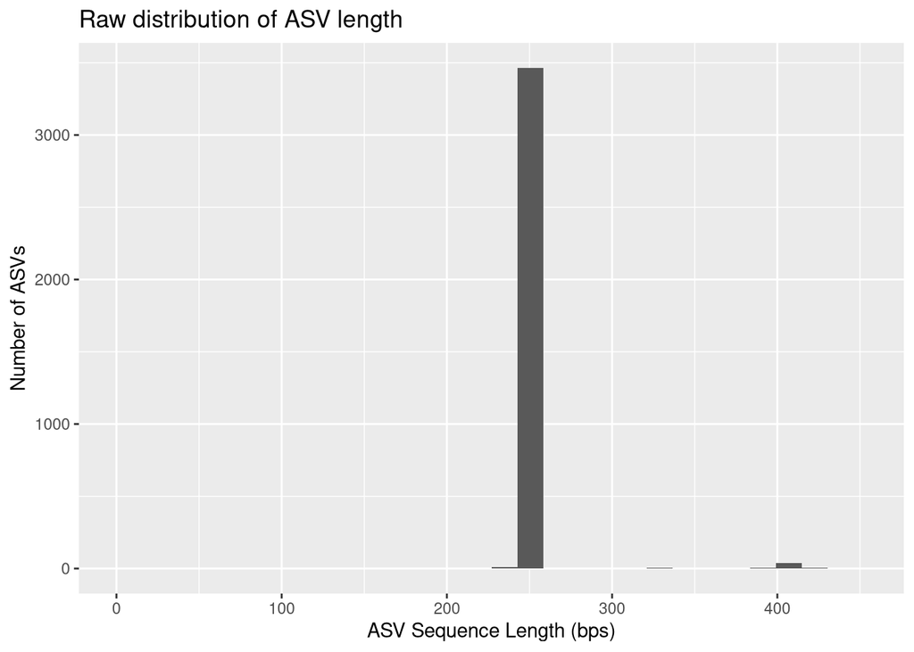

```r
# Inspect the distribution of sequence lengths of all ASVs in data set
# AFTER TRIM
data.frame(Seq_Length = nchar(getSequences(raw_ASV_table))) %>%
  ggplot(aes(x = Seq_Length )) +
  geom_histogram() +
  # include the x-axis scales
  scale_x_continuous(limits = c(0, maxLength_ASV + 5)) +
  labs(title = "Raw distribution of ASV length",
       y = "Number of ASVs", x = "ASV Sequence Length (bps)")
```

As we saw in the table, the length of the ASVs is mostly 245 base pairs.

## Trim ASV lengths

Now that we are pretty convinced that we have some spurious ASVs, we will trim ASVs that are higher or lower than 245 base pairs in this data set.

**NOTE:** This is another moment in our workflow where we are sub-setting only the “good parts” of our data to ensure the data quality we have at the end is the best of our ability based on the sequencing run.

```r
# TRIM THE ASVS
# Let's trim the ASVs to only be the right size, which is indeed 245!

# We will allow for a few
raw_ASV_table_trimmed <- raw_ASV_table[,nchar(colnames(raw_ASV_table)) == 245]

# Inspect the distribution of sequence lengths of all ASVs in dataset
table(nchar(getSequences(raw_ASV_table_trimmed)))
```

```
##
##  245
## 3160
```

```r
# What proportion of total ASV sequences are left in the data?
sum(raw_ASV_table_trimmed)/sum(raw_ASV_table)
```

```
## [1] 0.9084066
```

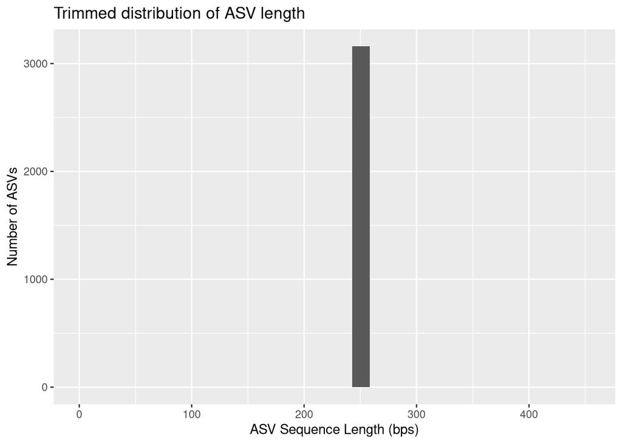

```r
# Inspect the distribution of sequence lengths of all ASVs in dataset
# AFTER TRIM
data.frame(Seq_Length = nchar(getSequences(raw_ASV_table_trimmed))) %>%
  ggplot(aes(x = Seq_Length )) +
  geom_histogram() +
  # include the x-axis scales
  scale_x_continuous(limits = c(0, maxLength_ASV + 5)) +
  labs(title = "Trimmed distribution of ASV length",
       y = "Number of ASVs", x = "ASV Sequence Length (bps)")
```

**Note the peak at 245 is ABOVE 3000 ASVs!** Now, we have ASV lengths that are only 245 bp and we can move forward onto the next quality control step: removing chimeras.

# Remove Chimeras

## What is a chimera?

In 16S rRNA gene sequencing, a **chimera** is an artificial DNA sequence that forms when two or more different DNA templates are mistakenly and erroneously fused together during PCR amplification. **Chimeric sequences do not represent real organisms and must be removed during data processing to avoid false species identifications!** Chimeras are natural artifacts in PCR, especially in high-cycle (>25 cycle) PCR reactions, which are typical in library preparation and sequencing workflows. They arise during:

1. *Incomplete Extension in Early PCR Cycles.* During early PCR cycles, a DNA fragment may partially amplify before the polymerase detaches. This incomplete product remains in the reaction mixture.
2. *Template Switching in Later PCR Cycles.* In subsequent cycles, the polymerase may bind to and extend a different but similar template, rather than the original one. This results in a hybrid (chimeric) DNA molecule made of two unrelated 16S rRNA gene fragments.
3. *There is increased chimera formation in high-diversity samples.* More diverse microbial communities increase the chance of chimeric formation due to similar overlapping sequences in the sample. Longer PCR extension times and too many PCR cycles (>30) increase chimera formation by allowing more template switching.

## Chimeras must be removed

- **Chimeras create false ASVs:** Chimeric sequences do not belong to any real microbial species, leading to artificial diversity in sequencing results.
- **Chimeras can mislead ecological interpretations** If not removed, they can inflate richness estimates and misrepresent community composition.

Therefore, chimera removal is an essential step in the analysis of 16S sequencing data to improve the accuracy of downstream analyses, such as taxonomic assignment and diversity assessment. It helps to avoid the inclusion of misleading or spurious sequences that could lead to incorrect biological interpretations.

```r
# Remove the chimeras in the raw ASV table
noChimeras_ASV_table <- removeBimeraDenovo(raw_ASV_table_trimmed,
                                           method="consensus",
                                           multithread=TRUE, verbose=TRUE)
```

```
## Identified 241 bimeras out of 3160 input sequences.
```

```r
# Check the dimensions
dim(noChimeras_ASV_table)
```

```
## [1]   96 2919
```

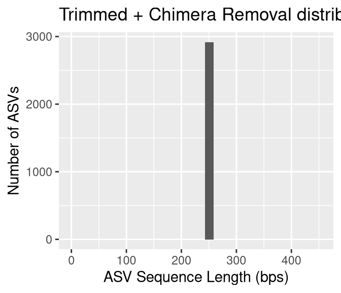

```r
# What proportion is left of the sequences?
percRetained_chimerasTrimmed <- sum(noChimeras_ASV_table)/sum(raw_ASV_table_trimmed)
percRetained_chimerasRaw <-sum(noChimeras_ASV_table)/sum(raw_ASV_table)

# Plot it
data.frame(Seq_Length_NoChim = nchar(getSequences(noChimeras_ASV_table))) %>%
  ggplot(aes(x = Seq_Length_NoChim )) +
  geom_histogram()+
  # include the x-axis scales
  scale_x_continuous(limits = c(0, maxLength_ASV + 5)) +
  labs(title = "Trimmed + Chimera Removal distribution of ASV length",
       y = "Number of ASVs", x = "ASV Sequence Length (bps)")
```

**Note the peak at 245 is now BELOW 3000 ASVs!** So, we have removed 241 ASVs, which were chimeras. This retained 98.05% of the trimmed ASV counts and only 89.07% of the raw merged ASV counts.

# Track the read counts

Here, we will look at the number of reads that were lost in the filtering, denoising, merging, and chimera removal.

```r
# A little function to identify number seqs
getN <- function(x) sum(getUniques(x))

# Make the table to track the seqs
track <- cbind(sapply(dada_forward, getN),
               sapply(dada_reverse, getN),
               sapply(merged_ASVs, getN),
               rowSums(noChimeras_ASV_table))

head(track)
```

```
##                                        [,1] [,2] [,3] [,4]
## 022um-Control_R1_filtered.fastq.gz     8051 8019 8015 8015
## 20210602-MA-ABB1F_R1_filtered.fastq.gz 4451 4391 4226 3534
## 20210602-MA-ABB1P_R1_filtered.fastq.gz 4082 4052 3737 3183
## 20210602-MA-ABB1W_R1_filtered.fastq.gz 6496 6481 6106 5053
## 20210602-MA-ABS1F_R1_filtered.fastq.gz 4233 4242 3960 3249
## 20210602-MA-ABS1P_R1_filtered.fastq.gz 4685 4709 4423 3808
```

```r
# Update column names to be more informative (most are missing at the moment!)
colnames(track) <- c("denoisedF", "denoisedR", "merged", "nochim")
rownames(track) <- sample_names

# Generate a dataframe to track the reads through our DADA2 pipeline
track_counts_df <-
  track %>%
  # make it a dataframe
  as.data.frame() %>%
  rownames_to_column(var = "names")

# Visualize it in table format
DT::datatable(track_counts_df)
```

|  | names | denoisedF | denoisedR | merged | nochim |
| --- | --- | --- | --- | --- | --- |
| 1 | 022um-Control | 8051 | 8019 | 8015 | 8015 |
| 2 | 20210602-MA-ABB1F | 4451 | 4391 | 4226 | 3534 |
| 3 | 20210602-MA-ABB1P | 4082 | 4052 | 3737 | 3183 |
| 4 | 20210602-MA-ABB1W | 6496 | 6481 | 6106 | 5053 |
| 5 | 20210602-MA-ABS1F | 4233 | 4242 | 3960 | 3249 |
| 6 | 20210602-MA-ABS1P | 4685 | 4709 | 4423 | 3808 |
| 7 | 20210602-MA-ABS1W | 5652 | 5690 | 5316 | 4437 |
| 8 | 20210602-MA-CEB1F | 5118 | 5093 | 4832 | 4136 |
| 9 | 20210602-MA-CEB1P | 6520 | 6544 | 6171 | 5053 |
| 10 | 20210602-MA-CEB1W | 6105 | 6133 | 5860 | 4826 |

[output cut: 86 more lines]

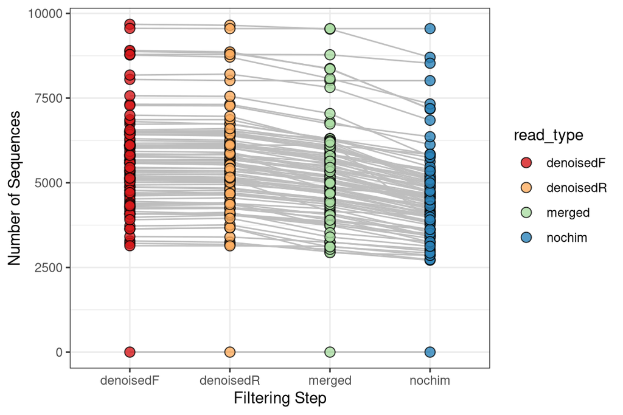

```r
# Plot it!
track_counts_df %>%
  pivot_longer(denoisedF:nochim, names_to = "read_type", values_to = "num_reads") %>%
  mutate(read_type = fct_relevel(read_type, "denoisedF", "denoisedR", "merged", "nochim")) %>%
  ggplot(aes(x = read_type, y = num_reads, fill = read_type)) +
  geom_line(aes(group = names), color = "grey") +
  geom_point(shape = 21, size = 3, alpha = 0.8) +
  scale_fill_brewer(palette = "Spectral") +
  labs(x = "Filtering Step", y = "Number of Sequences") +
  theme_bw()
```

# Assign Taxonomy

Here, we will use the silva database version 138!

```r
# Classify the ASVs against a reference set using the RDP Naive Bayesian Classifier described by Wang et al., (2007) in AEM
taxa_train <-
  assignTaxonomy(noChimeras_ASV_table,
                 "/workdir/in_class_data/taxonomy/silva_nr99_v138.2_toGenus_trainset.fa.gz",
                 multithread = 200)

# Add the genus/species information
taxa_addSpecies <-
  addSpecies(taxa_train,
             "/workdir/in_class_data/taxonomy/silva_v138.2_assignSpecies.fa.gz")

# Inspect the taxonomy
taxa_print <- taxa_addSpecies # Removing sequence rownames for display only
rownames(taxa_print) <- NULL
#View(taxa_print)
```

# Prepare data for export

## 1. ASV Table

Below, we will prepare the following:

1. Two ASV Count tables:
   1. **With ASV seqs:** ASV headers include the *entire* ASV sequence 245 bases.
   2. **with ASV names:** This includes re-written and shortened headers like ASV_1, ASV_2, etc, which will match the names in our fasta file below.
2. `ASV_fastas`: A fasta file that we can use to build a tree for phylogenetic analyses (e.g. phylogenetic alpha diversity metrics or UNIFRAC dissimilarty).

### Finalize ASV Count Tables

First, lets save the ASV table with the ASV sequence name and the ASV fasta file

```r
# Give headers more manageable names
# First pull the ASV sequences
asv_seqs <- colnames(noChimeras_ASV_table)
asv_seqs[1:5]
```

```
## [1] "GAGTGGCAAGCGTTATCCGGAATTATTGGGCGTAAAGCGTCCGCAGGCGGTCTGTCAAGT…"
## [2] "GAGTGGCAAGCGTTATCCGGAATTATTGGGCGTAAAGCGTCCGCAGGCGGTCTTGTAAGT…"
## [3] "AGGGTGCAAGCGTTAATCGGAATTACTGGGCGTAAAGCGCGCGTAGGTGGTTCGTTAAGT…"
## [4] "AAGGTCCAAGCGTTAATCGGAATTACTGGGCGTAAAGCGCGCGTAGGTGGTTTATTAAGT…"
## [5] "GAGTGGCAAGCGTTATCCGGAATTATTGGGCGTAAAGCGTCCGCAGGCGGCCCTTCAAGT…"
```

```r
# make headers for our ASV seq fasta file, which will be our asv names
asv_headers <- vector(dim(noChimeras_ASV_table)[2], mode = "character")
asv_headers[1:5]
```

```
## [1] "" "" "" "" ""
```

```r
# loop through vector and fill it in with ASV names
for (i in 1:dim(noChimeras_ASV_table)[2]) {
  asv_headers[i] <- paste(">ASV", i, sep = "_")
}

# intitution check
asv_headers[1:5]
```

```
## [1] ">ASV_1" ">ASV_2" ">ASV_3" ">ASV_4" ">ASV_5"
```

```r
##### Rename ASVs in table then write out our ASV fasta file!
#View(noChimeras_ASV_table)
asv_tab <- t(noChimeras_ASV_table)
#View(asv_tab)

## Rename our asvs!
row.names(asv_tab) <- sub(">", "", asv_headers)
asv_tab[1:5, 1:5]
```

```
##       022um-Control_R1_filtered.fastq.gz 20210602-MA-ABB1F_R1_filtered.fastq.gz
## ASV_1                                  0                                    598
## ASV_2                                  0                                    248
## ASV_3                               7747                                     48
## ASV_4                                  0                                    165
## ASV_5                                  0                                     20
##       20210602-MA-ABB1P_R1_filtered.fastq.gz
## ASV_1                                    417
## ASV_2                                    177
## ASV_3                                      0
## ASV_4                                    165
## ASV_5                                     18
##       20210602-MA-ABB1W_R1_filtered.fastq.gz
## ASV_1                                    881
## ASV_2                                    301
## ASV_3                                      0
## ASV_4                                    216
## ASV_5                                     29
##       20210602-MA-ABS1F_R1_filtered.fastq.gz
## ASV_1                                    501
## ASV_2                                    204
## ASV_3                                      0
## ASV_4                                    112
## ASV_5                                      0
```

```r
#View(asv_tab)
```

## 2. Taxonomy Table

```r
# Inspect the taxonomy table
#View(taxa_addSpecies)

##### Prepare tax table
# Add the ASV sequences from the rownames to a column
new_tax_tab <-
  taxa_addSpecies%>%
  as.data.frame() %>%
  rownames_to_column(var = "ASVseqs")
head(new_tax_tab)
```

```
##                                                                                                                                                                                                                                                 ASVseqs
## 1 GAGTGGCAAGCGTTATCCGGAATTATTGGGCGTAAAGCGTCCGCAGGCGGTCTGTCAAGT…
## 2 GAGTGGCAAGCGTTATCCGGAATTATTGGGCGTAAAGCGTCCGCAGGCGGTCTTGTAAGT…
## 3 AGGGTGCAAGCGTTAATCGGAATTACTGGGCGTAAAGCGCGCGTAGGTGGTTCGTTAAGT…
## 4 AAGGTCCAAGCGTTAATCGGAATTACTGGGCGTAAAGCGCGCGTAGGTGGTTTATTAAGT…
## 5 GAGTGGCAAGCGTTATCCGGAATTATTGGGCGTAAAGCGTCCGCAGGCGGCCCTTCAAGT…
## 6 AGGGTGCAAGCGTTGTCCGGAATTATTGGGCGTAAAGAGCTCGTAGGTCGTTTGCCGCGT…
##    Kingdom          Phylum               Class           Order           Family
## 1 Bacteria Cyanobacteriota      Cyanobacteriia Synechococcales     Cyanobiaceae
## 2 Bacteria Cyanobacteriota      Cyanobacteriia Synechococcales     Cyanobiaceae
## 3 Bacteria  Pseudomonadota Gammaproteobacteria Pseudomonadales Pseudomonadaceae
## 4 Bacteria  Pseudomonadota Gammaproteobacteria Pseudomonadales      SAR86 clade
## 5 Bacteria Cyanobacteriota      Cyanobacteriia Synechococcales     Cyanobiaceae
## 6 Bacteria  Actinomycetota      Actinobacteria      Frankiales  Sporichthyaceae
##                  Genus Species
## 1   Cyanobium PCC-6307    <NA>
## 2   Cyanobium PCC-6307    <NA>
## 3          Pseudomonas    <NA>
## 4                 <NA>    <NA>
## 5 Synechococcus CC9902    <NA>
## 6           hgcI clade    <NA>
```

```r
# intution check
stopifnot(new_tax_tab$ASVseqs == colnames(noChimeras_ASV_table))

# Now let's add the ASV names
rownames(new_tax_tab) <- rownames(asv_tab)
head(new_tax_tab)
```

```
##                                                                                                                                                                                                                                                     ASVseqs
## ASV_1 GAGTGGCAAGCGTTATCCGGAATTATTGGGCGTAAAGCGTCCGCAGGCGGTCTGTCAAGT…
## ASV_2 GAGTGGCAAGCGTTATCCGGAATTATTGGGCGTAAAGCGTCCGCAGGCGGTCTTGTAAGT…
## ASV_3 AGGGTGCAAGCGTTAATCGGAATTACTGGGCGTAAAGCGCGCGTAGGTGGTTCGTTAAGT…
## ASV_4 AAGGTCCAAGCGTTAATCGGAATTACTGGGCGTAAAGCGCGCGTAGGTGGTTTATTAAGT…
## ASV_5 GAGTGGCAAGCGTTATCCGGAATTATTGGGCGTAAAGCGTCCGCAGGCGGCCCTTCAAGT…
## ASV_6 AGGGTGCAAGCGTTGTCCGGAATTATTGGGCGTAAAGAGCTCGTAGGTCGTTTGCCGCGT…
##        Kingdom          Phylum               Class           Order
## ASV_1 Bacteria Cyanobacteriota      Cyanobacteriia Synechococcales
## ASV_2 Bacteria Cyanobacteriota      Cyanobacteriia Synechococcales
## ASV_3 Bacteria  Pseudomonadota Gammaproteobacteria Pseudomonadales
## ASV_4 Bacteria  Pseudomonadota Gammaproteobacteria Pseudomonadales
## ASV_5 Bacteria Cyanobacteriota      Cyanobacteriia Synechococcales
## ASV_6 Bacteria  Actinomycetota      Actinobacteria      Frankiales
##                 Family                Genus Species
## ASV_1     Cyanobiaceae   Cyanobium PCC-6307    <NA>
## ASV_2     Cyanobiaceae   Cyanobium PCC-6307    <NA>
## ASV_3 Pseudomonadaceae          Pseudomonas    <NA>
## ASV_4      SAR86 clade                 <NA>    <NA>
## ASV_5     Cyanobiaceae Synechococcus CC9902    <NA>
## ASV_6  Sporichthyaceae           hgcI clade    <NA>
```

```r
### Final prep of tax table. Add new column with ASV names
asv_tax <-
  new_tax_tab %>%
  # add rownames from count table for phyloseq handoff
  mutate(ASV = rownames(asv_tab)) %>%
  # Resort the columns with select
  dplyr::select(Kingdom, Phylum, Class, Order, Family, Genus, Species, ASV, ASVseqs)

head(asv_tax)
```

```
##        Kingdom          Phylum               Class           Order
## ASV_1 Bacteria Cyanobacteriota      Cyanobacteriia Synechococcales
## ASV_2 Bacteria Cyanobacteriota      Cyanobacteriia Synechococcales
## ASV_3 Bacteria  Pseudomonadota Gammaproteobacteria Pseudomonadales
## ASV_4 Bacteria  Pseudomonadota Gammaproteobacteria Pseudomonadales
## ASV_5 Bacteria Cyanobacteriota      Cyanobacteriia Synechococcales
## ASV_6 Bacteria  Actinomycetota      Actinobacteria      Frankiales
##                 Family                Genus Species   ASV
## ASV_1     Cyanobiaceae   Cyanobium PCC-6307    <NA> ASV_1
## ASV_2     Cyanobiaceae   Cyanobium PCC-6307    <NA> ASV_2
## ASV_3 Pseudomonadaceae          Pseudomonas    <NA> ASV_3
## ASV_4      SAR86 clade                 <NA>    <NA> ASV_4
## ASV_5     Cyanobiaceae Synechococcus CC9902    <NA> ASV_5
## ASV_6  Sporichthyaceae           hgcI clade    <NA> ASV_6
##                                                                                                                                                                                                                                                     ASVseqs
## ASV_1 GAGTGGCAAGCGTTATCCGGAATTATTGGGCGTAAAGCGTCCGCAGGCGGTCTGTCAAGT…
## ASV_2 GAGTGGCAAGCGTTATCCGGAATTATTGGGCGTAAAGCGTCCGCAGGCGGTCTTGTAAGT…
## ASV_3 AGGGTGCAAGCGTTAATCGGAATTACTGGGCGTAAAGCGCGCGTAGGTGGTTCGTTAAGT…
## ASV_4 AAGGTCCAAGCGTTAATCGGAATTACTGGGCGTAAAGCGCGCGTAGGTGGTTTATTAAGT…
## ASV_5 GAGTGGCAAGCGTTATCCGGAATTATTGGGCGTAAAGCGTCCGCAGGCGGCCCTTCAAGT…
## ASV_6 AGGGTGCAAGCGTTGTCCGGAATTATTGGGCGTAAAGAGCTCGTAGGTCGTTTGCCGCGT…
```

```r
# Intution check
stopifnot(asv_tax$ASV == rownames(asv_tax), rownames(asv_tax) == rownames(asv_tab))
```

# Write Output Files

Now, we will write the files! We will write the following to the `data/01_DADA2/` folder. We will save both as files that could be submitted as supplements AND as .RData objects for easy loading into the next steps into R.:

1. `ASV_counts.tsv`: ASV count table that has ASV names that are re-written and shortened headers like ASV_1, ASV_2, etc, which will match the names in our fasta file below. This will also be saved as `data/01_DADA2/ASV_counts.RData`.
2. `ASV_counts_withSeqNames.tsv`: This is generated with the data object in this file known as `noChimeras_ASV_table`. ASV headers include the *entire* ASV sequence ~250bps. In addition, we will save this as a .RData object as `data/01_DADA2/noChimeras_ASV_table.RData` as we will use this data in `analysis/02_Taxonomic_Assignment.Rmd` to assign the taxonomy from the sequence headers.
3. `ASVs.fasta`: A fasta file output of the ASV names from `ASV_counts.tsv` and the sequences from the ASVs in `ASV_counts_withSeqNames.tsv`. A fasta file that we can use to build a tree for phylogenetic analyses (e.g. phylogenetic alpha diversity metrics or UNIFRAC dissimilarty).
4. We will also make a copy of `ASVs.fasta` in `data/02_TaxAss_FreshTrain/` to be used for the taxonomy classification in the next step in the workflow.
5. Write out the taxonomy table
6. `track_read_counts.RData`: To track how many reads we lost throughout our workflow that could be used and plotted later. We will add this to the metadata in `analysis/02_Taxonomic_Assignment.Rmd`.

```r
# Write BOTH the modified and unmodified ASV tables to a file!
# Write count table with ASV numbered names (e.g. ASV_1, ASV_2, etc)
write.table(asv_tab,
            file = "data/01_DADA2/ASV_counts.tsv",
            sep = "\t", quote = FALSE, col.names = NA)

# Write count table with ASV sequence names
write.table(noChimeras_ASV_table,
            file = "data/01_DADA2/ASV_counts_withSeqNames.tsv",
            sep = "\t", quote = FALSE, col.names = NA)

# Write out the fasta file for reference later on for what seq matches what ASV
asv_fasta <- c(rbind(asv_headers, asv_seqs))
# Save to a file!
write(asv_fasta, "data/01_DADA2/ASVs.fasta")

# SECOND, let's save the taxonomy tables
# Write the table
write.table(asv_tax,
            file = "data/01_DADA2/ASV_taxonomy.tsv",
            sep = "\t", quote = FALSE, col.names = NA)

# THIRD, let's save to a RData object
# Each of these files will be used in the next step of our analysis!
# RData objects are for easy loading :)
save(noChimeras_ASV_table, file = "data/01_DADA2/noChimeras_ASV_table.RData")
save(asv_tab, file = "data/01_DADA2/ASV_counts.RData")

# And save the track_counts_df a R object, which we will merge with metadata information in the next step of the analysis in nalysis/02_Taxonomic_Assignment.
save(track_counts_df, file = "data/01_DADA2/track_read_counts.RData")
```

# Check Render Time

```r
# Take the time now that we are at the end of the script
end_time <- Sys.time()
end_time
```

```
## [1] "2025-03-05 13:57:00 EST"
```

```r
# Echo the elapsed time
elapsed_time <- round((end_time - start_time), 3)
elapsed_time
```

```
## Time difference of 8.43 mins
```